# パネルデータ分析 問題集

牧野、伊藤、山岸

2022-06-13

## 問題1

知識問題

1. パネルデータの特徴は何か、簡単に述べてください。
2. パネルデータ分析の利点は何か、述べてください。
3. パネルデータ分析の3つのモデルを列挙し、それぞれの概要を述べてください。

## 問題2 パネルデータ分析（airfare）

それぞれの路線において、市場集中度が高いほど、 運賃が高くなる傾向にあるのでは？

という仮説を検証してください。

この問題では以下のライブラリを使用するため、読み込むこと

```r
library(tidyverse)
library(lfe)
library(fixest)
library(wooldridge)
library(ggplot2)
```

この問題では以下のデータを使用するため、読み込むこと

データの読み込み

```r
data("airfare")
summary(airfare)
```

```
##       year            id            dist            passen
##  Min.   :1997   Min.   :   1   Min.   :  95.0   Min.   :   2.0
##  1st Qu.:1998   1st Qu.: 288   1st Qu.: 505.0   1st Qu.: 215.0
##  Median :1998   Median : 575   Median : 861.0   Median : 357.0
##  Mean   :1998   Mean   : 575   Mean   : 989.7   Mean   : 636.8
##  3rd Qu.:1999   3rd Qu.: 862   3rd Qu.:1304.0   3rd Qu.: 717.0
##  Max.   :2000   Max.   :1149   Max.   :2724.0   Max.   :8497.0
##       fare          bmktshr           ldist            y98            y99
##  Min.   : 37.0   Min.   :0.1605   Min.   :4.554   Min.   :0.00   Min.   :0.00
##  1st Qu.:123.0   1st Qu.:0.4650   1st Qu.:6.225   1st Qu.:0.00   1st Qu.:0.00
##  Median :168.0   Median :0.6039   Median :6.758   Median :0.00   Median :0.00
##  Mean   :178.8   Mean   :0.6101   Mean   :6.696   Mean   :0.25   Mean   :0.25
##  3rd Qu.:225.0   3rd Qu.:0.7531   3rd Qu.:7.173   3rd Qu.:0.25   3rd Qu.:0.25
##  Max.   :522.0   Max.   :1.0000   Max.   :7.910   Max.   :1.00   Max.   :1.00
##       y00           lfare          ldistsq          concen
##  Min.   :0.00   Min.   :3.611   Min.   :20.74   Min.   :0.1605
##  1st Qu.:0.00   1st Qu.:4.812   1st Qu.:38.75   1st Qu.:0.4650
##  Median :0.00   Median :5.124   Median :45.67   Median :0.6039
##  Mean   :0.25   Mean   :5.096   Mean   :45.28   Mean   :0.6101
##  3rd Qu.:0.25   3rd Qu.:5.416   3rd Qu.:51.45   3rd Qu.:0.7531
##  Max.   :1.00   Max.   :6.258   Max.   :62.57   Max.   :1.0000
##     lpassen
##  Min.   :0.6931
##  1st Qu.:5.3706
##  Median :5.8777
##  Mean   :6.0170
##  3rd Qu.:6.5751
##  Max.   :9.0475
```

1. 概観する（ヒストグラムを作成する）

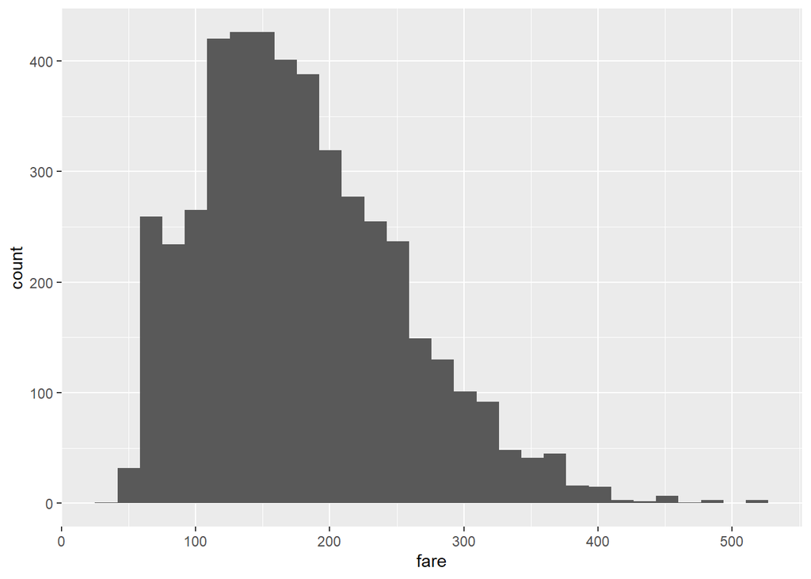

```r
#ggplotを活用する
hg_fare <- ggplot(data=airfare,aes(x=fare))+geom_histogram()
hg_fare
```

2. データの加工 運賃の分布には偏りがあるため、対数変換によって必要に応じて分布の歪みを解消する。

```r
#例えば、data1というデータフレームに、numberという変数をIn_numberに対数変換して追加する時
data1$In_number <- log(data1$number)
```

3. 固定効果モデルを推定する feolsを活用して、固定効果モデルを測定する。

```r
#基本的な関数
data(trade)
model1 = feols(y ~ x1+x2+x3+x4 | id+firm+year+group, trade)
```

パイプの前には変数、パイプの後に固定効果を置く x1, x2, x3, x4 ： 回帰させたい変数

id, firm, year, group ： 固定効果

trade ： サンプルで扱っているデータ

4. 結果を可視化する

※以下はtradeという別分析の結果

出力

```r
summary(model2)
```

```
## GLM estimation, family = gaussian, Dep. Var.: Euros
## Observations: 38,325
## Fixed-effects: Origin: 15,  Destination: 15,  Product: 20,  Year: 10
## Standard-errors: Clustered (Origin)
##               Estimate Std. Error  t value   Pr(>|t|)
## log(dist_km) -66754618   14306507 -4.66603 0.00036385 ***
## ---
## Signif. codes:  0 '***' 0.001 '**' 0.01 '*' 0.05 '.' 0.1 ' ' 1
## Log-Likelihood:  -766,357.9   Adj. Pseudo R2: 0.008938
##            BIC: 1,533,328.0     Squared Cor.: 0.304899
```

```r
etable(model2)
```

```
##                                          model2
## Dependent Var.:                           Euros
##
## log(dist_km)    -66,754,618.0*** (14,306,507.4)
## Fixed-Effects:   ------------------------------
## Origin                                      Yes
## Destination                                 Yes
## Product                                     Yes
## Year                                        Yes
## _______________  ______________________________
## S.E.: Clustered                      by: Origin
## Observations                             38,325
## Squared Cor.                            0.30490
## Pseudo R2                               0.00901
## BIC                                 1,533,328.0
## ---
## Signif. codes: 0 '***' 0.001 '**' 0.01 '*' 0.05 '.' 0.1 ' ' 1
```

5. 固定効果の推定値を出す

```r
fixed_effect <- fixef(model2)
summary(fixed_effect)
```

```
## Fixed_effects coefficients
##                           Origin Destination  Product    Year
## Number of fixed-effects       15          15       20      10
## Number of references           0           1        1       1
## Mean                     3.9e+08    88900000 24300000 8140000
## Standard-deviation      45400000     4.2e+07 38500000 6020000
##
## COEFFICIENTS:
##   Origin:        AT        BE        DE        DK        ES
##           350900000 389800000 447100000 370300000 443400000 ... 10 remaining
## -----
##   Destination:       AT       BE        DE       DK        ES
##                52280000 74990000 175700000 56720000 110700000 ... 10 remaining
## -----
##   Product: 1         2        3         4         5
##            0 100100000 35740000 103800000 -22420000 ... 15 remaining
## -----
##   Year: 2007    2008   2009    2010    2011
##            0 3567000 246700 3756000 7927000 ... 5 remaining
```

## 問題3 パネルデータ分析（人事データ）

指定の[エクセルデータ](https://docs.google.com/spreadsheets/d/1357_Xghyi5EwZe3_1EtulcXlfzAbD3qY/edit?usp=sharing&ouid=111491956916703212192&rtpof=true&sd=true)において、独立変数を職能資格等級、被説明変数を業績給として、  
仮説を立て、その仮説を固定効果モデルによって検証してください。

やり方

1. 分析するデータファイルをRに読み込む（openxlsxライブラリ等を活用する）
2. 変数と固定効果を特定する
3. 欠損値を処理する
4. 必要に応じて、変数の対数変換を行う
5. 固定効果モデルの推定を行う
6. 結果を表示する 等級の変化が業績給に対してどのような影響を与えているか、分析結果を解釈してください。